# 第七章：芝加哥学派的持续意义

安德鲁·阿伯特

翻译：周忆粟

版本：2021.11.08

［译者注］：本文取自《院系与学科》（*Department and Discipline*，1999），第七章。图为译者添加。pdf页边码为原书页码。仅仅供学术交流。

通过上一章，我们脱离了先前章节充满历史和理论的基调，进入了有点更具规范性的基调。本章延续了这一开处方的趋势，并为其添加了一道争辩性的边缘——继承自它作为演讲台演说的源起——这与本书其余部分审慎的基调有点不协调。但是*现在*（the present）向变化开放，其方式是*过去*无法实现的，因此谨慎似乎不适合当下。我在这里要谈的是我和许多其他人所认为的目前濒临的危机状态，这个学科由阿尔比昂·斯莫尔（Albion Small）和其他人如此勇敢地建立起来。然而，我对这种情况的解读让我回到了第一章和第二章，因为我认为贯穿芝加哥传统的诸主题提供了构建社会学新时代的工具。

芝加哥的传统现今已有一个世纪了。当然，周年纪念通常是告别。一百周年纪念有时与垂死联系在一起，就像钻石禧年可能揭示了女王的无关紧要，而金婚纪念揭示出许多婚姻业已死亡。但我们并不一定要如此。活生生的社会关系每天都在被人颂扬，周年纪念则让这些兴奋更突出。

那么，我们对芝加哥大学一百年历史的社会学有什么看法呢？这仅仅只是悼念的时刻吗？毕竟，芝加哥社会学的主导地位已经过去了半个世纪。尽管二战后芝加哥的传统在戈夫曼（Erving Goffman）、贝克尔（Howard Becker）、贾诺维茨（Morris Janowitz）等人身上重新焕发了活力，但自其主导的年代以来，芝加哥许多最杰出的校友更多地属于社会学主流，而不是严格意义上的芝加哥传统：像斯托佛（Samuel Stouffer）这样的方法论学家，像豪瑟尔（Philip Hauser）和凯菲茨（Nathan Keyfitz）这样的人口学家，像本迪克斯（Richard Bendix）和威伦斯基（Harold Wilensky）这样的宏观社会学家。尽管如此，芝加哥传统的核心提供了对理解当代社会学如何前进的核心见解。因此，我不在这里颂扬芝加哥的传统。死者才被人歌颂。[^1]

# 1 社会学的困境

显然，如果我认为芝加哥学派给出了答案，我也必须认为首先存在一道问题。或者至少是一个困境。社会学的突出问题——华盛顿大学惨遭关闭的社会学系和最近耶鲁大学社会学系的死里逃生——也许没有那些更加微妙的问题重要。其中一项微妙的问题是，社会学未能持续吸引能与人类学、政治学和经济学相媲美的研究生。不管我们对标准化考试和平均学分绩点表示多大的怀疑，社会学与这些学科之间的差异依然太大，太一致了，不容我们忽视（D’Antonio 1992；Huber 1992）。另一项指标是社会学不再作为政府的政策顾问，这一角色几乎完全被经济学所取代。在学术会议的安全范围内，我们可能轻视经济学家，但只有他们才能对王子耳语（例如，见Rhoads 1978）。

另一项令人沮丧的指标是我们分裂成不相连的环节分头行事。ASA年会汇集了在学术风格、方法论实践或实质性关注方面几乎没有共同点的团体（见 Ad Hoc Committee 1989）。诚然，这在某种程度上是一种活力的象征；我们对接受某些差异持开放态度。但我们的小派系表明，事实上，我们大多数人都不愿意接受新的*想法*；那些有新想法的人被诚恳地邀请到别处安营扎寨，有时在ASA内部，有时在ASA之外。因此，理性选择理论进入社会学的前景将历史社会学家推向了障碍。后现代主义在其他地方也引起了同样的反应。甚至女性主义的命运也显示出同样的分裂的自满。在人类学、历史学和政治学中，关于女性主义理论的争论十分激烈。但尽管社会学在诸社会科学中吸收了最多的女性研究者，而其知识结构和风格在回应女性主义思想方面却没有丝毫改变。[^2]

或许最令人沮丧的是，社会学已经失去了它的许多兴奋。我们仍然用伊莱贾·安德森（Elijah Anderson）的《转角处》（*A Place on the Corner* 1978）或戴维·哈勒（David Halle）的《美国的工人》（*America’s Working Man* 1984）或米切尔· 邓奈尔（Mitchell Duneier）的《斯利姆的桌子》（*Slim’s Table* 1992）等书来吸引本科生，但我们读这些书只是为了教他们，当然也不鼓励我们的学生去写这些作品。我们太忙于科学。然而，即使是我们的科学也显露出一种疲惫的感觉。我们订阅期刊，但不阅读。对版面的竞争使我们的方法和风格变得井井有条，以至于作者有时似乎对他们自己的材料感到厌烦；他们只是通过星标系数、低下的$R^2$和适当明智的理论进步主张来完成。今天谁会发表邓肯（Otis Dudley Duncan）在《美国的职业结构》（*The American Occupational Structure*）里使用的综合同期群分析？他承认这一分析在很大程度上是在胡乱摆弄（布劳和邓肯［1967］2019，第239页）。[^3]今天哪份主流期刊会发表欧文·戈夫曼（ Goffman 1956）的「尴尬理论」，或伊贡·比特纳（Egon Bittner 1967）对贫民区警察的观察，或者塔尔科特·帕森斯（Talcott Parsons）对美国生活的臃肿浮夸诠释（例如，Parsons［1939］1954）？

也许，正如理论家们经常告诉我们的那样，他们阵营里的情况会好一些。毕竟，在当今的社会学学科中，理论和方法已经几乎没有什么联系了。对ASA诸分会联合会员的研究非常清楚地表明了理论部分与经验主流部分的隔离，参考文献列表见证了彼此在另一方土地上的巨大沉默。[^4]但是理论家那些基于书本的文献很少在经验主义者们基于论文的文献上改进。它只是影响了「大深刻」[^5]而不是实证主义，根据他们哲学假设的正当性而不是他们的统计技术的通用性来评判其作者。当然，我们不能指责理论家与经验主义主流的关联意义，事实上不能指责理论家与经验现实的关联意义。经验现实似乎没有引起他们的注意，除非它涉及到整个民族或文明的历史。[^6]

简而言之，社会学已经退化为公式——经验性、理论性和历史性的公式。我们不再有足够的热情去冒险，去传播非正统的思想，去彼此的地盘上偷猎。我们已经放弃了对真实世界的书写，而是隐藏在调查变量、历史力量和理论抽象的程式化世界中。我想知道，我们中有多少人能声称从大学开始就在一些非学术性的社会环境中度过了甚至哪怕一个整年？

我认为社会学的问题首先是智识上的。外部的政治威胁，吸引学生的困难，学科的支离破碎，这些都反映了一个弱点。从根本上说，这是思想／想法的弱点（a weakness of ideas）。我们社会学家已经很久没有看到一个让我们非常兴奋的想法，一个可以改变我们的智识实践的想法，一个可以让我们想去阅读那些期刊的想法。我认为芝加哥学派正代表了这样一个想法：托马斯（W. I. Thomas）、帕克（Robert Park）、伯吉斯（Ernest Burgess）和他们的学生展现了一种理论上的洞察力，可以使我们走出目前的困境。我希望在这里发展这一想法，考虑一下它与当前理论和方法论实践的关系，并勾勒出学者们为更新它所作的最初努力。

# 2 芝加哥的洞察力

一段时间以来，把芝加哥学派说成含有任何理论观点都显得过时。一幅广为流传的形象描绘了一个经验主义者的芝加哥，它从未与马克思、韦伯和涂尔干一起攀上理论的高峰，也从未逃脱过向善论的社会福利主义。人们认为，充其量芝加哥学派发起了大规模社会学研究的实践，并在城市研究和犯罪学等领域贡献了基本的经验工作。（例如，参见Ritzer 1988对芝加哥的描绘，或是更友好的作品，如Bulmer 1984）

但芝加哥似乎与理论无关，仅仅是因为我们——我们中的大多数——都是替代了芝加哥学派的范式的坚定拥趸，我在这里称其为「变量」范式。在那个范式中，在它对欧洲经典的解释中，理论化就是对抽象的关系做出断言，比如「性别」、「资本主义」、「教育」和「官僚主义」。我们大多数人认为这种断言实际上是严肃社会学的本质，无论我们是历史社会学家、还是地位获得模型研究者、或者性别社会学家。在这样一个世界观中，芝加哥学派——它从不相信像「性别」和「科层制」这样的抽象概念——从定义上说就与理论无关。但也许社会学目前的困境应该让我们在罗列芝加哥的理论立场之前暂停一下判断。

用一句话来说，芝加哥学派过去认为——而且现在仍认为——如果不理解特定社会行动者在特定社会时间和地点的安排，就无法理解社会生活。另一种说法是，芝加哥学派认为从社会（通常是地理）空间和社会时间的情境中抽象出来的社会事实没有任何意义。社会事实*定位于某处*（*located*）。这意味着在共时性分析中要关注社会关系和空间生态，正如在历时性分析中要关注过程。每一项社会事实都是情境性（situated），被其他的语境事实所包围，并通过一个与过去情境相关的过程而产生[^7]

一项直接的推论是，变量不仅在现实中不存在，并且即使作为一种名物主义惯例（a nominalist convention），它们也极具误导性。因为变量的想法是一个尺度的想法（idea of a scale），无论情境为何，它都具有相同的因果意义：例如，该观点认为，不管一个人的其他特性如何，「教育」可以对「职业」产生「一种效应」，无论这些特性是其他过去的经历、其他个人特征，还是朋友、熟人以及人际连接。在基于变量的思维中，人们允许一些「交互作用」（interactions）修饰在情境中的这个单一因果意义，但是变量独立性的基本形象包含在「控制了其他变量后的净值」一词中，目的是通过实验或统计操作来发现这种净效应。芝加哥的观点一直认为，净效应的概念是社会科学的胡说八道。在社会世界中的任何事情都不会是「［控制了］其他变量后的净值」。所有的社会事实都在情境中定位。那为什么还要假装它们不是呢？[^8]

说这种观点目前几乎没有拥护者实属过于轻描淡写了。大多数当代社会学并不以社会事实的位置或关系为中心。当然，时间会出现，但仅仅是时钟的滴答声而已。人员和事件不在其中，变量在其中。情节和过程不会贯穿其中，因果箭头会贯穿其中。这一点在空间方面甚至更明显。大多数社会学论文都假定不相关的个体，不管是工人、公司还是协会。这些个体是「分析单位」，而不是社会关系的行动者。然而，纵观芝加哥的著作，我们发现了典型的案例历史图表——例如，思拉舍（Frederic Thrasher 1927，p.70）的帮派生涯图表——我们发现一张又一张的地图上点缀着妓院、精神分裂者、住宿酒店、企业或任何其他感兴趣的东西。在芝加哥的著作中，我们找到了时间和地点。

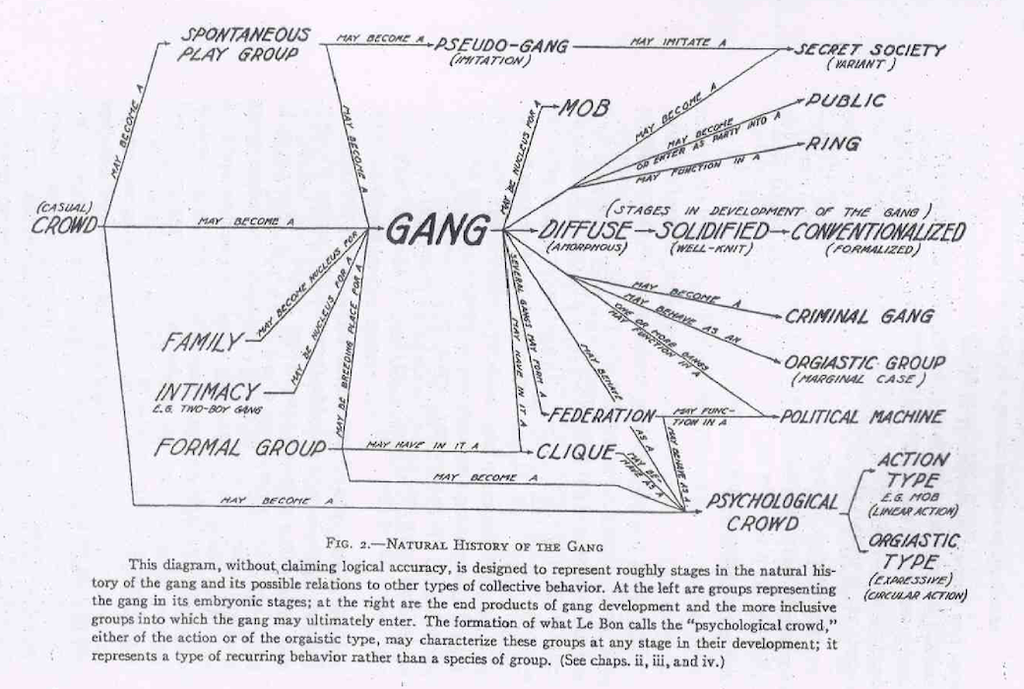

图1. 思拉舍绘制的帮派生涯

当然也有一些社会学家——有些是芝加哥的后裔，有些不是——他们认真对待在社会时间和空间空维度上的定位／位置。历史社会学家虽然在其方法论写作中相当注重因果关系，但在实践中却十分重视时间定位问题。研究职业的社会学家仍然保留着埃弗里特·休斯（Everett Hughes）那芝加哥式的对时间过程的强调，正如社会运动的学生们保留了罗伯特·帕克（Robert Park）的观点一样。当然，源自于或受符号互动论挑战的微观社会学——老芝加哥最具体的直系后裔——也保留了对时间的强烈重视。[^9]

至于空间位置，是社区研究和网络研究的学生们保持了这种兴趣。对前者来说，它直接来自芝加哥，因为社区是芝加哥的中心问题之一。相比之下，网络理论家对位置的兴趣则从其形式化的根源上获得。网络分析的主要方法与数学社会学家有关：詹姆斯·科尔曼的聚类分析和哈里森·怀特（Harrison White）的结构对等。虽然两人都做过芝加哥的教员，但他们的社会网络思想很少归功于该共同体。[^10]

# 3 关于时间和地点

我希望本书前面的章节已经有力地证明了芝加哥传统的存在，这种传统远远超出了第一芝加哥学派的界限。尽管如此，在这一章中，我将以芝加哥在1920年代和30年代的标志性作品为基础进行论述。

这些芝加哥作者并不是简单地论证「社会事实在社会时间和空间中都有情境」，并就此结束。他们区分了——或许我们可以称之为——情境性的程度（degrees of contextuality）。[^11]首先，考虑一下时间过程。芝加哥学派的一项基本概念是「自然史」（natural history）。自然史是一种遵循相对可预测过程的时间模式。它可以被周遭因素所改变或塑造，但它的一般序列可以被理解为一个整体，而不仅仅是偶然的细节（contingent details）。在经典著作中，这一概念最明显的例子是爱德华兹（1927）对革命的分析。对爱德华兹而言，革命按照一种内在逻辑展开。它们可能会被改变或重塑。它们可能会失败。但总的逻辑是有规律的。

相比之下，思拉舍（Thrasher 1927）的分析认为发展中的帮派更容易受到周围情境的影响。资源的可用性、竞争对手的力量、环境的物理结构，所有这些都可以塑造一个帮派的生涯，这种情境的塑造显然比爱德华兹在革命中看到的更为强烈。我们可以称具有更大情境依赖性的时间过程为「生涯」（careers），以区别于自然史。

最后，在广泛的芝加哥作品中，情境性是如此重要，以至于人们不能再聚焦于一项单一的过程。相反，我们必须研究一个相互交织的过程的整个网络。其中最著名的例子是佐鲍尔的《金岸与陋街》（*The Gold Coast and the Slum* 1929）。乍一看——我记得这是我读研究生时的反应——这本书似乎是一部写得很好但又有点漫无目的的芝加哥近北区历史。但事后想来，佐鲍尔的分析是芝加哥学派「互动领域」（interactional field）概念的最清晰表述。近北区由它的情境所定义；对佐鲍尔来说，社区的边界是相互约束的边界，这些约束定义了那里发生的事情——有些是地理约束，有些是社会约束，有些是经济约束。在这样一个社区中，每一个群体的运动都是如此地依赖于其他群体的运动，因此单独书写他们中的任何一个群体都没有意义。一个人只能把一个互动领域作为整体来写。

那么在时间过程中，芝加哥的作者们看到了三种不同程度的情境性：自然史及其相对较少的情境性，生涯及其相对较多情境性，互动领域中的情境性如此之多，以至于个体过程被紧密地编织在一起。请注意，所有这些概念都定义了诸时间*过程*。也就是说，不可能把这些社会事实从它们的*时间*情境中剥离出来。有争议的是，*给定*一个时间过程，它与*社会*情境的独立程度有多大？

我们可以问恰恰相反的问题。给定一组*空间*结构或社会结构，它们在时间情境中的独立性如何？在这里，芝加哥人作出了类似的区分。相当于自然史的是自然区域（natural area）。在定义自然区域时，帕克谈到「一种单纯的地理表达转变成一个领域，也就是说，一个有感情、传统和自身历史的地点（locality）……每一个地点的生命都有它自己的某种势头（momentum），或多或少地独立于更大的围绕它的生命圈和利益圈」（Park 1925，p.6）。在这里，就像在自然史中一样，出现的是一种相对独立于周围环境的实体，但它以地点来定义其内部的一切。因此，在安德森的《流浪汉》（1923，见下图）中，有一幅关于西麦迪逊街的流浪汉聚集「主干道」小地图。街道本身和当地流浪汉社区的社会动态与沿街商店的布局密切相关。

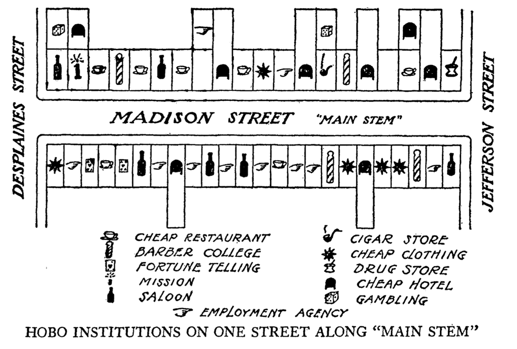

图2. 安德森描绘的贫民区

正如安德森的例子所表明的那样，自然区域和周围的城市之间实际上存在着一种深层次的隐性关系。贫民区（hobohemia）由一定的（对外来临时工的）经济需求和城市内交通、经济和社会结构的力量造成。但这些力量在短期内是恒定的，所以把贫民区与环境的关系看作很重要但非偶然，把这种关系当成是暂时固定的自然区域很有意义。因此自然区域是社会结构，由社会情境决定，但暂时不需要分析其时间背景。

显而易见，这种思维导致从「无序」（disorganization）角度对社会问题的生态分析。各个自然区域都有不同程度的组织和无序；社会问题被认为与后者直接相关。这是芝加哥学派关于精神疾病（Faris and Dunham 1939）、离婚（Mowrer 1927）以及最重要的犯罪和青少年越轨（Shaw and McKay 1942）工作的基础部分。[^12]

自然区域模型与基于变量的技术相对一致，这具有一定的历史意义。随着芝加哥学派的衰落，自然区域的地理位置仅仅成为了描述个体的另一个变量。但概念的理论内容在转移过程中丢失了，因此到罗宾逊（William Robinson）发出的著名的对生态相关性和生态谬误（1950）的抨击时，只剩下了原始生态概念的一抹影子，隐含在群体层面变量（group-level variables）的概念中。[^13]

芝加哥人通常认为自然区域之间存在明显的联系，使得空间效应的模式取决于各种周遭环境因素。不可避免地，这涉及到向时间性的转变。在帕克和伯吉斯1921年的文本中，给出的芝加哥概念武器库的核心是诸如「接触」、「冲突」、「同化」和「适应」之类的概念，这些概念描述了由其他环境群体相互对等决定群体的时间模式。这里的情况类似于芝加哥学派处理时间情境的方法中生涯的概念。正如在生涯中有比自然历史更重要的*社会*情境和偶然性一样，*时间*环境在这些「区域生涯」中的作用也比在自然区域中的作用更大。

沃思（1928）对芝加哥犹太人聚居区的讨论就是这种「区域生涯」类型。犹太人聚居区与［时间环境］的关系——与城市扩张那更大的力量、与犹太企业不断变化的赞助关系、与世代继承的时间模式和连续不断的移民浪潮的关系——都塑造了犹太人日常生活的经验。沃思把他的分析集中于犹太社区，正如斯拉舍（1927）在分析帮派生涯时，保留了对个别帮派的关注。但是两位作者都考虑了比自然史或自然区域更广泛的偶然性；接续的犹太社区的发展就是这个群体在复杂的社会和地理空间中的「生涯」。

在极限情况下，一个社会结构的时间情境范围变得如此之大，以致于［对它的分析］再次要求抛开个别的案例，并把它作为一整个互动领域来讨论。佐鲍尔的《金岸与陋街》再次提供了一则最清晰的例子，因为互动领域的概念不仅涉及到一系列的社会情境，也涉及到一系列的时间情境。近北区的故事不仅涉及到经济结构和移民人口构成等方面变化的长期过程，还涉及到社区的当地继承等短期过程，以及诸如分组房居民的流转等更为迅速的过程。在空间上，互动领域不仅涉及到整个区域从城市的大规模分化脱离出来和与城市的相互依赖，也涉及到较短范围的现象，如教区会众流动所产生的教会混杂以及近北区本身各分区在经济上的相互依赖。

与自然区域不同，互动领域的概念并不容易转移到变量世界。尽管如此，在某些分支领域，特别是历史社会学领域，它仍然活得很好。伊曼纽尔·沃勒斯坦（Immanuel Wallerstein）的《现代世界体系》（*The Modern World-Syste*［1974］2013）和我自己的《职业系统》（*The System of Professionals*［1988］2016）都描述了这种互动领域。以我更了解的情况为例，我关于职业的论点基本上认为，职业本身就像是在芝加哥城市中互相推挤的族裔群体，职业所从事的工作相当于城市本身的自然地理和社会地理。那么，职业的历史就是争夺地盘的历史。一个人不能写下单一职业的历史，因为该职业太依赖于它周围的其他职业在做什么。人们只能描述跨职业冲突的场域——规则、策略、计谋以及互动的副产品。这一场域不时出现更大的力量：技术和组织发展引起的职业工作的变化，这相当于城市交通和经济模式的变化。这些导致了互动领域中进一步的级联变化（cascading changes）。互动领域也有规则，很像城市的政治规则，等等。然渊源似乎有些遥远，但我的书在本质上是对一个古老的芝加哥概念的阐述。

然后，我们可能会想到一个三乘三的图表，其中的行维度描述了时间情境性的增加程度，列维度描述了社会情境性的增加程度（见表1）。我基本上提出了这样一个论点：芝加哥的作者们几乎总是在最后一行或最后一列展开（最情境化的）工作，而这两者相交于 [3, 3] 单元格——在互动领域的概念中相交，互动领域假设了社会和时间情境的多个层次。在交互场域的概念中，我们必须像佐鲍尔、沃勒斯坦或我一样，从个案的层面出发，开始描述整个场域中相互作用的规则和规律。情境的偶然性是如此复杂，以至于人们无法直接研究单个案例，也无法作出任何预测，除非是最普遍类型的预测。

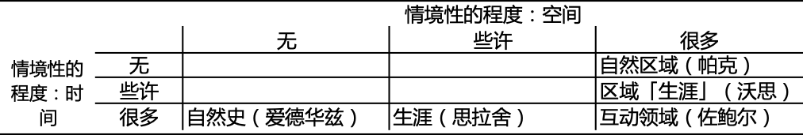

表1. 芝加哥学派的情境

稍后我将讨论这个小表格的其他单元格。就目前而言，我只想强调的是，在这种对情境和偶然性的整体关注中，隐含着对社会结构的一致看法。芝加哥的作者们认为，社会结构是一套在不断变化和对等决定（reciprocal determination）的过程中出现的暂时性稳定。社会世界由行动者组成——相互决定的行动者，有时是故意的，有时完全不可预见。但芝加哥愿景的基石在于*位置*（location），因为在社会时间和空间中的位置引导着对等决定的展开。所有的社会事实都位于特定的物理场所和特定的社会结构中。它们也位于一个或多个继承、同化、冲突等过程的时间逻辑中。这意味着芝加哥的愿景是一种嵌入时间的社会结构，一个过程中的结构。

我不无讽刺意味地读了这篇总结。历史社会学家不是已经告诉过我们，马克思主义在1970年代社会学中的普遍重要性在于它给了社会学家一种思考变化和过程的方法吗（Abbott 1991a）？韦伯的理性化和其他过程不是在同一时期也取代了帕森斯化的韦伯理论，并带来了同样的效果吗？为什么当代社会学完全忘记了芝加哥学派的观点？为什么他们不是我们的「经典社会学」？[^14]

部分原因在于芝加哥的作品介于当代与经典之间。当我们读一本经典的时候，我们忽略了［其中］陈旧的意识形态和奇怪的措辞，以便把注意力集中在文本中探讨永恒、永久、持久的问题的部分。因此，我们把涂尔干作为一名重要的社会理论家，尽管他的新法团主义（neocorporatism）很愚蠢；把韦伯作为一名重要的社会理论家，尽管他嗜爱轻率的分类；把马克思作为一名重要的社会理论家，尽管他专注于一种现在早已不复存在的工厂制度。但是，芝加哥学派温暖的行文却愚弄了人们，误把它作为当代作品来阅读。[^15]接着，帕克诚挚的种族适应理论、克雷西对「滥交倾向」的描述（1932，p.xiii），以及斯拉舍对「流浪癖」的分析（1927，第十章）都立马使读者感到尴尬。因此，问题之一是芝加哥学派似乎既没有老到足以成为经典，也没有足够年轻到以成为当代。

另一个问题是单纯的势利。芝加哥的写作缺乏欧洲人的拉丁文素养和高调。我们的社会学理论家，像亨利·詹姆斯（Henry James）及其之前的许多其他学者，认为美国人的原始见解太多，不符合他们的口味。他们更喜欢欧洲的复杂成熟，他们设法以某种方式忘记了实用主义——直接塑造了芝加哥社会学的美国哲学——对像哈贝马斯（Harbermas 1971）这样的欧洲理论家的影响。

不管忽视芝加哥的原因是什么，芝加哥的核心位置性概念对今天的我们有着特殊的重要性，因为它可以帮助我们协调理论与经验工作。大多数社会学理论，无论是欧陆的还是美国的，当代的还是经典的，都把社会事实放在各自的情境中。社会事实涉及过程、关系、行动和互动。但是，我们目前的大多数经验工作都是关于去情境化的事实，这些事实与过程、关系和行动之间只存在微弱的联系。与我们目前的方法相比，一种建立在「情境下的行动」基础上的一般经验性方法，可以更有效地阐述我们的一般理论传统。

每一位当代社会学家都必须高度关注理论和经验工作之间的鸿沟。当然，每个子领域都有自己的理论家和理论，正如默顿（Robert Merton 1948）在他关于中层理论（middle range theory）的著名评论中所敦促的那样，这些区域理论家（我们也许可以这样称呼他们）确实比通才更密切地与经验工作联系在一起。但是，他们使用的是关于因果关系，关于效应，关于情境的概念语言，不管他们是否愿意承认，这都隐含了的一种一般理论，而这个一般理论实际上来源于现代社会学的去情境化方法论范式。现在让我更详细地考虑一下这个范式。

# 4 论社会学方法与理论的关系

把社会事实从它们的情境中剔除的想法并非随着1930年代老芝加哥学派的衰落而开始。从某种意义上说，任何社会统计都会这样做，毕竟社会统计数据始于十七世纪。自1880年代霍勒里斯穿孔卡片机（Hollerith machine）问世以来，统计学家已经能够对社会统计数据进行广泛的交叉分类。这项任务得益于同一时期发明的相关性概念（correlation）。交叉分类和相关性主要用于描述，即「类型x的人也可能是y和z」。这种式样的类型学在只在微弱的种程度上可以算是情境思维，因为它将变量的值集中到其他变量的「情境］中。但这已经是朝着去情境化方向迈出的重要一步：因为它从单个变量构造类型，而不是将其作为格式塔或涌现的方式进行分析。[^16]

社会学形式化统计方法的第一名主要倡导者是富兰克林·吉丁斯（Franklin Giddings），他是二十世纪前三十年哥伦比亚社会学系的主导人物，也是霍华德·奥德姆（Howard Odum）、威廉·奥格本（William Ogburn）和F·斯图尔特·查宾（F. Stuart Chapin）等杰出学生的导师。吉丁斯的《归纳社会学》（*Inductive Sociology* 1901）把因果理解作为社会学的目标，并将因果关系视为必要致因的一种充分组合（a sufficient combination of necessary causes）。但在这段激动人心的密尔式介绍之后，这本书继续给出的基本上是一长串与各种社会现象有关的变量，并附有如何进行测量的提示。社会学规律在万有引力定律或理想气体定律之后形成，因此本质上是对经验相关性的总结。在我的三乘三表中，吉丁斯对 [1, 1] 单元格感兴趣，这个单元格在空间或时间上都具有最小程度的情境性。同样清楚的是，从深层次上讲，他的理论思想只是简单的经验概括。因果关系，无论原则上多么有趣，似乎非常需要一座尚在建构中的基础——经验性概化（empirical generalization）的基础。

与吉丁斯的方法及其变量、相关性的形成主要对照是所谓的「社会调查」：对社区、机构和社会问题进行的基础广泛的实地研究，通常由慈善组织运动中的社会工作者或其助手进行。这些都是有重点的研究，通常使用多种方法论，但始终在其直接情境中保留事实，因为调查人员想弄清楚为什么会发生特殊的社会问题，以及如何发生，以便改变这些问题。有对特定行业工人的访谈研究、将官方统计与描述和案例研究相结合的犯罪报告，以及涉及研究团队的整个社区研究。例如，《米德尔敦／中镇》是社会调查运动的最后一批伟大产物之一（林德和林德［1929］1999）。调查运动没有理论目的。例如，它从来没有试图发现诸如「工作」和「对家庭的承诺」之类的抽象概念之间的关系——这种「规律」是吉丁斯项目的核心——而是研究（继续这个例子）在某个特定社区和某个特定产业情境中，某个特定工人群体与其家庭的关系。[^17]

然后，在经验层面上，芝加哥学派在许多方面是社会调查传统和吉丁斯的「科学」社会学的混合体（吉丁斯厌恶调查［Bulmer 1984，p.67］）。尽管帕克和伯吉斯花了相当长的时间来区分他们的「由科学指导的」工作与调查运动的改良主义（Bulmer 1984，第五章；Turner and Turner 1990，p.25），但对于今天的读者而言，芝加哥学派的作品读起来更像是社会调查文献，而不是吉丁斯学派的作品。[^18]

然而，芝加哥学派有着理论上的雄心。这使它的程序与调查运动的程序有所不同，并使该学派的写作具有连贯性，而调查运动的产物却缺乏这种连贯性。正如我已经指出，芝加哥理论侧重于社会事实的位置性和情境偶然性。[^19]这种理论承诺包含了芝加哥学派对不同方法的混合，因为如果致因的影响由环境因素塑造，那么没有任何致因具有统一的效应，具体的理论必须是关于［社会］力量组合（constellations of forces）的理论，而不是关于个别致因的理论。发现这种组合的最快方法是通过案例研究，因为纯粹的［数量上可能的］组合使得在总体层面上研究这一问题变得困难。更一般地说，只有民族志、统计学、生活史和组织历史的折中组合，才能充分体现社会事实的多层次时空情境。[^20]

相比之下，吉丁斯的因果关系概念是必要致因的充分组合，它们本身被认为是抽象的——驱使人们直接研究独立单元的不同性质。只有在因果关系从根本上取决于情境的前提下，追求芝加哥式的研究才有意义。对于 [1, 1] 单元格中的最小情境性而言，没有必要浪费时间来定位事实。那么在我看来，芝加哥学派代表了对吉丁斯项目的一次明显的智识进步，因为它解决了社会生活的复杂性。但这进步却是在一种坦率的科学框架内完成的。它用一种更为细致的情境主义方法取代了一种特别简单的变量方法。

这种强调情境的新观念有着杰出的的智识谱系，这在帕克和伯吉斯的文本中显而易见。伟大的欧洲来源是古斯塔夫·拉岑霍费尔（Gustav Ratzenhofer）和盖奥尔格·西美尔（Georg Simmel）。令人惊讶的是，前者在美国的主要阐释者是经常被人诟病的阿尔比昂·斯莫尔；因此，早在西美尔的学生罗伯特·帕克到来之前，芝加哥的学生就已经听到了「生态」理论——他们从历史主义者那里听到，正如我们今天从历史社会学家如查尔斯·拉金（Charles Ragin 1987）那里听到的类似的论点一样。[^21]在这些欧洲来源中，还增加了威廉·托马斯（W.I.Thomas）和乔治·赫伯特·米德（George Herbert Mead，通过埃尔斯沃斯·法里斯［Ellsworth Faris］）的独特贡献，他们两者提供的社会心理学没有涂尔干那「社会化的麻醉剂」或塔尔德（Gabriel Tarde）（与吉丁斯）知识渊博的模仿者那样的机械和抽象。托马斯和兹纳尼茨基（Znaniecki）的《身处欧美的波兰农民》（1918-20）表明，社会环境的复杂性如何在个体生活中发展起来，然后通过个体反弹来重塑环境及其制度。因此，个体与社会的关系本身被重新概念化为彼此之间的一种相互情境（mutual context）。

那么在我看来，芝加哥学派通过情境性这一中心思想将科学化和调查传统结合起来，并取得了决定性的进展。在使情境性成为芝加哥学派的中心焦点时，我背离了在芝加哥关于社会生活的写作中通常强调主体性、价值观和主体间性的作用的传统（例如，在某种程度上的Harvey 1987a，以及所有的符号互动论历史学家，从赫伯特·布鲁默［Herbert Blumer］本人以降；例如，见Rock 1979）。我认为主体间性的重要方面与其说是它的主观性特征，不如说是它的关系性特征。事实上，我觉得那些在社会学转向「文化」的新浪潮中看到其救赎的人——往往把这一趋势与芝加哥学派或其通过布鲁默的世系联系起来——犯了同样的错误。关注意义之间的关系才是最重要的，而不是简单地研究意义，这可以而且已经被用可能想象到最木讷的方式来做了。

在使情境性成为芝加哥学派思想的中心时，我也定义了芝加哥对过程的关注——很多人以前已经注意到了——这在逻辑上与「芝加哥对位置的关注」相关，无论是物理的还是社会的位置。在这样做的时候，我当然有选择地进行了阅读。我在这里的目的不是全面研究这个学派的复杂性。正如我们所见，其他人已经对此进行了很好地研究。相反，我在这里的目的是提取学派的中心思想，并将其带回到活跃的社会学意识的瞩目位置。这就是我所说的将芝加哥学派的著作作为经典文本来阅读。

后来的历史表明，芝加哥学派对情境性的综合很快失败了。许多力量促成了这次失败。有些是制度性的。洛克菲勒纪念基金在1932年枯竭。帕克离开芝加哥前往菲斯克大学。大学的新校长罗伯特·梅纳德·哈钦斯（ Robert Maynard Hutchins）对社会科学不感兴趣。但是其它的力量是智识上的，这些力量更为重要。[^22]

一方面，到了1930年代，布鲁默通过强调芝加哥方法中象征性、主体间性的一面，并通过挪用米德的社会心理学（有些人说这是徒劳；见 Harvey 1987a，p.161），奠定了符号互动主义的基础。在这一过程中，他将像波兰农民这样更为折衷的芝加哥作品抨击为「不科学」，因为它的分类并没有从资料中直接生成。因此，布鲁默接受了社会学的科学目标，但通过一方面将客观主义、定量研究和基于变量的方法与另一方面的主观主义、定性研究和基于案例的方法相结合，从而进一步推动了社会学的分裂。[^23]（正如我在前几章中指出的，将先前交错的二分法统一成一组压倒性的对立，在社会学系里布鲁默和奥格本之间的个人对立中得到了实现。）布鲁默也错过了关于情境的观点，认为以变量为基础的方法的中心问题在于它们未能捕捉到情形的主观模糊性（subjective ambiguities），而不是它们对更普遍的因果关系中情境决定论的否定，在这其中主观性问题仅仅只是一部分。[^24]

但芝加哥衰落中更重要的力量是1930年代民意调查和市场调查的兴起。这是对吉丁斯变量范式的一次大大改进的版本。极端派由保罗·拉扎斯菲尔德（Paul Lazarsfeld）领导。拉扎斯菲尔德倾向于纯粹的操作主义社会科学，故意忽视因果过程和理论——对此他几乎没报以任何希望（Turner and Turner 1990，p.105；p.114）。（科尔曼［Coleman 1990，p.89］说拉扎斯菲尔德「很难理解社会学理论。」）他的原型项目是关于消费者态度的市场研究。该研究的最终目的并不是要弄清楚消费者为什么会这么想，而只是找出他们偏爱的产品（见Lazarsfeld and Rosenberg 1955，p.396-98）。[^25]

去情境化是这样一个项目的核心，部分原因是消费者的口味会在一种关于当前口味的充分情境化理论发展出来之前发生变化，部分原因在于营销人员在调查和购买情况下无法让「其它［变量］保持不变」。通过快速发展的抽样学科，对特定社会属性必要的去情境化得以完成，这不仅使个体与朋友、熟人等等的社会背景分离开来，还故意忽略了一个单独变量在其他变量的情境中［的现实］，以达到对变量空间「更完整」的认识。抽样不仅将情境效应驯服为单纯的交互作用，还因此产生了数据集，其中情境因果关系的水平被有意地最小化。这将使整整一代社会学家把互动／交互当作好像是一种方法论上的麻烦，而不是社会现实发生的方式。[^26]

与拉扎斯菲尔德一样，温和派调查研究的领导者塞缪尔·斯托佛认为，只有现代调查分析才能产生一门学科的基石（参见，例如Stouffer［1950］）。斯托佛在他著名的论文（1930）中强调了调查研究与芝加哥学派之间的对比，这篇论文测试了四位学生同事作为态度评判者的速度和效率，并与一组编码协议进行比较。这些编码协议在很短的时间内产生了相同的答案，斯托佛据此认为这是一份决定性的证据，即编码协议是社会研究的首选方法。但是当然，通过提出「什么是编码一个变量最快的方法」这问题，他已经设计了他的答案。1930年代，案例研究和调查方法之间争论的焦点不在于调查能否更快地找到变量；这显然是事实。相反，焦点在于变量的概念——把社会事实从它们的情境中拿出来——首先是否是一种明智的概念？关于这一点，斯托佛优雅的实验并不能说明什么。由于斯托佛深深地致力于变量的概念，正如他后来的陈述所清楚地表明的那样，一般理论「不能为我们提供相互关联的命题，即如果给定 x2和 x3，那么 x1导致 x4的可能性很大」（1950，p.359）。理论的目的是为这些关于变量的可测试陈述提供演绎来源，如果一项理论没有提供这些推论，那么它就太模糊了因而无用。变量就是现实。[^27]

调查研究操作主义的实际重要性在于它能适应罗纳德·费雪（Ronald Fisher）和他的同事们在1920年代发明的同样可操作的统计程序（参见Anderson［1989］关于这些程序日益占主导地位的讨论）。拉扎斯菲尔德本人更喜欢他深奥的「潜在结构方法」。但是对于不太熟练的人来说，有一些针对特定操作目标设计的费雪式方法——在费雪的例子中被用来决定肥料在某一特定地域是否有用。（斯托佛在1930年代早期曾与皮尔逊和费雪进行过研究［Bulmer 1984，p.179］）毫无疑问费雪式析因设计（factorial design）可以辅助因果理论；尽管相反的是：如果一个人有一种有效的因果理论，则更容易检验假设。（有关概述，请参见Kempthorne 1976）对因果关系的关注是后来出现的（Bernert 1983；Abbott 1998）。与此同时，未来的费雪派和保守派之间主要斗争的是关于情境性因果关系的问题。费雪和其他大多数生物统计学家都通过实验设计来处理情境效应。即便如此，费雪的统计方法还是遭到了耶日·内曼（Jerzy Neyman）的精彩的情境论攻击，他在1930年代中期抨击了弗朗西斯·耶茨（Francis Yates）。内曼指出整个过程都依赖于一项无法验证的假设，即情境（交互）效应表现良好（Traxler 1976）。令人惊讶的是，内曼的话并未引致任何研究。（毕竟是他本人完成了关于抽样的基础性工作）实际上，对费雪方法中非理论性的攻击——精彩但徒劳——已经持续了几十年，最新的来自伯克利的无与伦比的戴维·弗里德曼（例如，David Freedman 1987）。

新的变量革命的创造者们看到，通过将社会事实从它们的直接情境中移除，人们可以让它们获得新的推论统计的力量。一旦实现了概念上的飞跃，即「变量的取值」在各种情况下都可比较，则所有的假设检验方法——相关方法、回归分析、因子分析，都将适用。即使是一名坚定的情境主义者也必须承认，调查方法和统计数据的结合是激进的也是令人兴奋的。与之前的情境主义、互动主义的洞察力一样，它也催生了社会学非凡的繁荣，如拉扎斯菲尔德、贝雷尔森（Bernard Berelson）和高德特（Hazel Gaudet）的《人民的选择》（*The People’s Choice*［1944］1968）、斯托佛等人的《美国士兵》（*The American Soldier* 1949）、贝雷尔森、拉扎斯菲尔德和麦克菲（William McPhee）的《选举》（*Voting* 1954）、李普塞特的《政治人》（*Political Man*［1960］2011）、科尔曼的《青少年社会》（*The Adolescent Society* 1961）以及布劳（Peter Blau）和邓肯的《美国的职业结构》（*The American Occupational Structure*［1967］2019）。这是一份非常杰出的名单。[^28]

如果你花时间重读这些书，你会发现它们粗犷、新鲜、令人兴奋。重读布劳和邓肯，可以感受到作者强烈的兴奋感。这是邓肯渴望尝试一下变量范式的最终一道褶皱。具有讽刺意味的是，结构方程方法是由罗伯特·帕克的芝加哥同事——伟大的生物学家休厄尔·赖特（Sewell Wright）开发的。《美国的职业结构》以叙事的形式写成，令当代读者大吃一惊。在每一章中，作者都会引导读者逐步了解他们所做的事情，而不是按照某种适当「科学的」或逻辑顺序来呈现。因此，作者是在场的和可见的。他们对数据缺陷的极度失望一次又一次地出现。他们坦率地承认他们预设了很强的统计和方法论假设，以及这些假设如何违背社会过程的合理观点。而他们的歉意很简单：也许激进的假设会产生令人兴奋的结果。出于四处洋溢的兴奋感，即使是毫无同情心的读者也会允许他们尝试那些假设，只是为了看看会发生什么。与情境主义范式一样，变量范式也产生了有吸引力和振奋人心的作品。[^29]

到了1960年代，变量范式建立了一座完整的社会分析大厦。多亏了拉扎斯菲尔德和其他人，该范式的主要的支柱来自商业调查文献——市场调查和民意调查。但它也接管了经验社会学。当伯纳德·贝雷尔森和加里·斯坦纳（Gary Steiner）发表了他们关于「行为科学现在对人类行为的认识」（1964，p.3）的总结时，这一范式达到了顶峰。书中的大部分「真相」（书名为《人类行为：研究结果一览表》［*Human Behavior: An Inventory of the Findings*］）实际上是双变量关相关性，有时有一到两个控制因素。至于事情为何发生则提及很少。[^30]

变革很快就到来。1960年代，社会学家开始接受结构方程方法中一直隐含的概率性因果关系图景。小休伯特·布拉列克（Hubert Blalock Jr. 1964）和其他作者从物理科学中借用了可能因果（probable causality）的概念，以证明他们的研究是正确的。与市场研究人员和生物学家们不同，使用变量模型的社会学家开始认为它们的主效应代表着因果力量。他们的文章暗示，性别、科层制和收入等变量可以在社会世界中「行事」（do things）。[^31]

因果意象的接管通过世代更替来实现。到了1960年代，在「前-变量范式」下接受训练的一代人开始消失。新的学生们学习这些方法，不是为了辅助更一般的分析，也不是为了快速解决互动主义范式下的经验问题。相反，在真正的库恩意义下，他们从方法中学习了一系列关于社会现实的假设，这些假设从根本上塑造了他们对社会世界的看法。由于其方法否定了任何他们无法理解的社会事实，范式逐渐变得自我封闭。到了1970年代，许多社会学家把社会世界想象成一种广义的线性现实（Abbott 1988a）。这种范式的封闭性甚至支配了子领域的理论家，而默顿希望理论家们能阻止这种封闭性。甚至类似约翰·迈耶（John Meyer）这样的作者，在宣告发现组织研究中的新制度主义时，也坚持用双变量、去情境化（「其他条件相同」）的假设来阐述（见Meyer and Rowan 1977 和 Scott and Meyer［1983］1991）。

正是这种对「因果分析」的最后一步转变，在理论和方法之间制造了真正的深渊。像斯托佛这样的人一只脚踏在旧范式，一只脚迈入新范式。斯托佛在一个以民族志为主的学系接受训练，但他自己却离开了这个系。他深深地相信吉丁斯的归纳法，并梦想着人们能够创造出在经验意义上可进行决定性检验的演绎理论（Stouffer 1950）。塔尔科特·帕森斯（斯托佛在哈佛大学与他共事）也相信同样的事情，尽管他希望把主要精力投入到理论的形成中；尽管他称之为的理论，是指比斯托佛说的要抽象得多的事情。在那部续作中，帕森斯的理论从未具体说明任何经验意义，但暂时，两人支持理论和方法在目前的和解，这使社会学在1950年代末和60年代初获得了巨大的发展。在哥伦比亚大学，默顿和拉扎斯菲尔德之间发展了相似但更亲密的协同关系。[^32]

但因果论远不止于此。一旦经验社会学家开始认为主效应实际上代表的不仅仅是一种分析上的便利，他们在现实社会行动中就失去了与学科的理论基础的联系。变量范式始于奥格本、斯托佛、邓肯和拉扎斯菲尔德通过变量的概念将新统计方法与社会学思维的结合。因果论限制这座桥只能单向通行。

因此，变量范式从未真正更新过。今天，它又老又陈旧。我在本章开头所描述的智识枯竭实际上是变量范式的枯竭。经过多年杰出而重要的工作，它已经失去了使我们兴奋的能力。在某种程度上，它失去的兴奋感，是由于自我陶醉的技术细节（米尔斯［1959／2017，p.105］说的「讲究形式但空洞无物的天真精巧」）。在某种程度上，它与真实的人失去了联系，不仅与作为读者的真实的人，而且作为分析对象也是如此。正如我已经说过的，它在某种程度上失去了与社会理论的联系，而社会理论过去一直是并将继续主要是关于社会行动和互动的。

但也许最重要的是（或唯一重要的是），乐趣已经没了。今天，当邓肯尝试另一次牵强的计算时，我们再也看不到他的大关注。我们从来没有看到任何人的大关注。[^33] 今天，新方法不可避免地涌现出新的结果——例如，《政治人》中新的调查使得描绘政治生活的总体图景成为可能——也已经不见了。我们再也不会以那样的方式感到惊讶。现在我们只是在填写细节。变量的概念是个好主意。但它作为令人兴奋的知识来源的日子已经过去了。

# 5 社会学方法论的未来

现在，你可能会认为我要说的是，如果我们读芝加哥学派，聆听它的信息，就会拨云见日，社会学会变得令人兴奋，决策者们会争着敲开我们的大门，等等。但那是胡说八道。芝加哥学派和变量范式的发展都依赖于——我在这里扮演一名好芝加哥人的角色——事物的形势（conjunction of things）。需要的不仅仅是好理论。在这两种情况下，大量的方法和分析技术早已准备就绪。芝加哥学派直接建立在长期的社会调查传统上。直到开始利用费雪派的分析机制前，变量范式也是寸步难行。因此，除非我们手头有方法将其付诸积极的经验实践，吸收芝加哥经典作品中的情境主义信息不会给我们什么好处。好消息是，这些方法正在等待我们。

让我从必要事项开始。情境社会学的方法论必须将我上面概述的芝加哥学派的基本概念应用到某种经验实践中。我们需要发现自然史的方法——长期的、一致的事件模式。我们需要分析生涯的方法——具有实质性环境决定因素的复杂序列。我们需要描述互动领域的方法。我们还需要研究复杂的空间相互依存，并使这种依存在时间维度上越来越结构化，直到我们再次达到互动领域的描述和测量。

请注意，我没有对所需的数据类型进行限定陈述。回归情境主义的一项中心原因是，它将把长期分离的社会学的各种类型结合在一起。正如我之前所说，历史社会学家经常讨论自然史、生涯和相互动领域。在互动主义传统中，很多人都在讨论空间的相互依存。我们的理论家确实根据行动来阐明他们的理论，而行动往往在时间和空间上结构化。在接下来的内容中，我将主要关注情境论的*实证主义*、*形式化*方法。因为它们是本学科最亟需的，幸运的是，这些方法似乎随处可见。[^34]

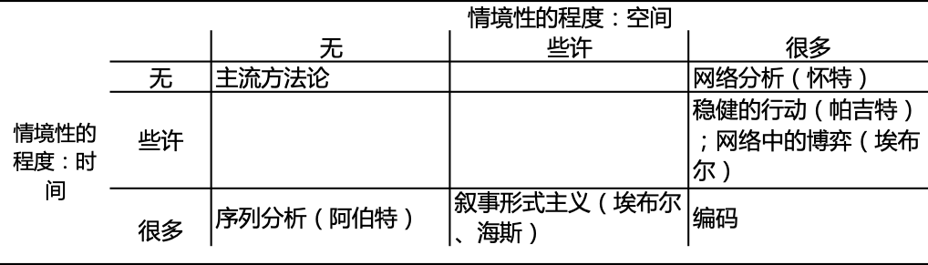

表2. 情境主义者的方法论实例

最后，我想讨论一些开始发展这种方法的工作。我的意思不是说这些新方法实际上是将使社会学发生革命的特殊技术；相反，它们说明了将产生使社会学发生革命的技术的思维方式。再一次，我继续考虑我的表格的高度情境化单元格。

我从对社会情境的研究开始，因为关于它的研究比对时间情境的研究要多，主要是在所谓的网络分析中。网络分析有大量的经验结果。因此，爱德华·劳曼（Edward Laumann）和戴维·克诺克（David Knoke）的《组织化的国家》（*The Organizational State* 1987）使用网络分析来揭示国家政治中一种复杂、不断变化的结构，这种结构通过标准的基于变量的技术完全不复可见。位置是这里的一项中心主题，正如其在劳曼的所有工作中一样。网络分析的经验成果反映了一套同样强大的理论基础，主要由哈里森·怀特和他的学生发展起来。网络思维经验性和理论性的一面共同呈现了一个比变量范式中的任何东西都更加密切统一的研究社会现实的方法。当然，网络思维以一种令主导范式极为尴尬的方式提出了情境决定的问题，正如怀特1970年出版的《机会链》（*Chains of Opportunity*）一书所述，该书塑造了从公务员到精神病医生和州警察群体的对劳动力市场的研究。（关于「空缺链」系统的回顾，见Chase 1991；关于网络分析的一般来源，见上文引用来源，注10。）

一些大胆的研究者正在将网络分析推向时间复杂性（表2中的 [2, 3] 单元格）。彼得·埃布尔（Peter Abell 1990a）开始将他对叙事相似性的形式化分析与理性选择行动模型结合起来。其结果是一个「网络中的博弈」（games in networks）的概念。另一个例子是约翰·帕吉特（John Padgett）对美第奇政党在佛罗伦萨建立的长达一个世纪的联系网络的分析（Padgett and Ansell 1993）。帕吉特运用从怀特的块模型（blockmodeling）发展而来的方法，以优雅的细节描绘了亲属关系、经济和政治网络的缓慢、经常是偶然的构建，最终赋予了科西莫·德·美第奇（Cosimo de’ Medici）「稳健行动」的能力，行动在很大程度上独立于他的控制或联盟（正是劳曼和克诺克的组织无法采取的那种行动）。与当代许多社会学理论一样，帕吉特直接关注的是结构中的行为。（怀特就这个主题写了一本理论书［White 1992］）

对时间模式和情境决定的研究也逐渐出现了同样的方法论发展。许多理论家一直致力于形式化模型的研究，特别是托马斯·法拉罗（Thomas Fararo）和约翰·斯科夫雷茨（John Skvoretz）（例如，他们1984年的作品）。但在这里，我们也看到了实用的经验方法的发展（评论见Abbott 1992b，1995b）。

这些问题中的第一个直接涉及到跨单元的叙事比较和分类这一经典问题：表2的 [3, 1] 单元格，其中时间情境很强，但单元基本上互相独立。这是一道实际的问题：帕克强调自然史、生涯和其他类型的时间模式是否正确？我自己在所谓的序列分析方面的工作集中在这里。我用标度法分析了美国医生职业化的叙事，清楚地表明［获取］地方权力优先于［建立］地方知识（Abbott 1991b）。我还使用了更深奥的技术——计算机科学中的序列比较算法——来分析音乐家的职业生涯（Abbott and Hrycak 1990）和福利国家的历史（Abbott and DeViney 1992）。关于这些研究的回顾述评，见阿伯特和蔡（Abbott and Tsay 1998）。

其他人——主要是大卫·海斯（David Heise）和彼得·埃布尔——则专注于涉及几个相互依赖的行动者的更为复杂的互动式叙事。海斯的方法（见Heise［1989，1991］和 Corsaro and Heise［1990］）源于他试图以一致的方式编写复杂的民族志叙事。这些方法产生了复杂故事的逻辑结构，可以在同一类型的实例中（例如，与警察争论）或不同类型（例如，比较与警察的争论和学术研讨会上的争论）之间进行比较。一个很好的例子是格里芬（Larry Griffin 1993）对私刑的分析。埃布尔（1987，1990b，1993）采取了一种不同的方法（强调数学而不是逻辑）对复杂叙事进行了某种程度上类似的编码。埃布尔对消费者合作社的研究表明，在叙事（和因果关系）条件下，结果惊人的相似性是如何出现的，而这些条件却似乎惊人地不同。其他作者（例如，Padgett 1981）也尝试过别的技巧。[^35]

在批评家们看来，无论是强调时间情境还是强调空间情境的研究，所有这些研究都存在一个重要的缺陷。它们缺乏「因果分析」，它们没有告诉我们「关键变量是什么」。但那就是它们的全部观点。自1965年以来在社会学中出现的因果关系是如此的具体化。事实上，社会生活只不过是重复性结构中反复出现的行为模式。这些方法，每一种都以自己的方式，聚集在时间和社会情境中对社会活动的模式的直接分析上，而这正是芝加哥学派的核心。它们告诉我们什么是关键的实际模式，而不是什么是关键的变量。后者是我们非社会学想象力的虚构。[^36]

像帕克和伯吉斯，像奥格本和斯托佛一样，在这些新的情境主义范式中工作的人们已经发现他们的方法论在社会学本身之外。哈里森·怀特和彼得·埃布尔把他们的物理学博士学位很好地用于形式化情境结构。我主要是从生物学和计算机科学中借来的。查尔斯·拉金（1987）的定性比较分析——一个情境主义的变量框架版本——最初来自电气工程。

虽然其中一些借用的技术需要认真的数学训练，但涉及时间或空间模式分类的大量问题却不需要。碰巧的是，复杂模式的分类工作在当前计算机科学文献中占了相当大的比例。这些用于模式匹配的动态规划（dynamic programming）方法在生物学、计算机科学、认知心理学等相关领域有着广泛的应用。毫无疑问，它们是目前正在开发的各种数据分析技术中最普遍的一套。因为它们可以应用于多个维度的模式，它们最终将适用于比较网络，就像我用它们来比较叙事一样。（有关当前的概述，请参阅Abbott［1993］中引用的资料来源）[^37]

试想一下，如果我们不仅可以告诉政策制定者，「那么，如果您在这个问题上投入x金钱，那么问题的增长将比明年少15％」。但是假设我们可以说：「好吧，如果您在这个问题上投入x金钱，那么a和b可能会发生，如果a发生，那么也许接着是c，但是如果a和b都发生，那么是c的可能性就很小，并且因为 c对于d来说是必不可少的，而d正是您努力达到的，那么除非您可以避免b，否则您将无法通过这种方式解决这个问题」。想象一下，如果那并不只是一个我们所有人都能够且确实在解释回归结果时进行的思想实验，而是应用于政策经验数据的标准方法的直接结果。那确实是政策科学。事实上，生产它的方法是可能的。它们只是在等待我们的想象力。

六十年前，社会学发生了一场知识革命——变量革命。正如经常发生的那样，这场革命被许多参与者误解了。斯托佛认为变量是通向社会学真理的捷径，尽管他仍在情境主义、互动主义范式中理解这些真理（Turner and Turner 1990，107）。奥格本认为变量是使社会学科学化的一种方式，而不是在一个已经确立的领域内改变范式。

今天我们站在旅程的终点。变量范式已经又老又旧。对我们来说，幸运的是，我们不仅有伟大的互动主义理论遗产等待重新发现，同时，许多社会学家已经开始开发研究情境中行动的方法，这些方法反过来又可以利用大量的模式识别技术。因为这一点，我们现在可以创造一种「实证主义」，与我们自己的理论遗产提出的问题相协调。我们现在有了将社会事实还原到时间和空间情境中的经验力量。我们可以直接观察特定社会行动者在特定的社会时间和地点的社会行动。[^38]

在我看来，我们根本没有陷入危机。恰恰相反。社会学正处在一次新的大繁荣之前。有新的方法可以借用。等待分析的问题比以往任何时候都更加紧迫和令人兴奋。最重要的是，我们拥有芝加哥学派留给我们的情境主义、互动主义传统的理论和经验工作遗产。这项工作为社会学的发展提供了基础和范例。这样就没有必要为芝加哥的传统写一篇告别词了。死者才被人歌颂。

# 参考文献

参考文献见：https://www.dropbox.com/s/7waa9xcxu0hhoc6/DaDbib.pdf?dl=0

[^1]: 这篇文章引发了很多评论。令人惊讶的是，有助益的评论（和可观的粉丝邮件）不仅来自我认识的人，而且还来自陌生人。因此，实际上我在这一章得到的帮助比我写过的其他任何东西都要多。以下所有人都发表了实质性评论：丽贝卡·亚当斯（Rebecca Adams）、琼·奥尔德斯（Joan Aldous）、玛戈·安德森（Margo Anderson）、詹姆斯·科尔曼（James Coleman）、克劳德·费希尔（Claude Fischer）、杰弗里·戈德法布（Jeffrey Goldfarb）、唐纳德·莱文（Donald Levine）、大卫·梅因（David Maines）、道格拉斯·米切尔（Douglas Mitchell）、约翰·莫德尔（John Modell）、约翰·帕吉特（John Padgett）、莫西·波斯顿（ Moishe Postone）和查尔斯·蒂利（Charles Tilly）。本文原为1992年4月10日在南方社会学学会发表的ASA索罗金讲座（ASA Sorokin Lecture）。我稍微修改了一下，但保留了原始的演说风格。毕竟，它的一个主要观点是社会学已经变得过于冷静。
[^2]: 关于历史社会学，参见Abbott（1991a）。ASA的比较历史社会学的分会（Section on Comparative Historical Sociology）在1991年赞助了一场题为「理性选择理论与历史社会学」的会议，这几乎成为一场猎巫。关于女性主义，可以参考乔治·瑞泽尔（George Ritzer 1988）的当代理论文本，其中有一个关于女性主义的单独部分，不是由瑞泽尔，而是由两位受邀的女性撰写的。分头行事而非合并的模式非常清晰。另见Stacey and Thorne（1985）。然而，有些人认为这种裂变在社会科学中是很普遍（例如，Levine 1981）。
[^3]: ［译注］邓肯这么写道：「这个讨论的最后一个主题是后一个解释的提出，该解释建立在这样一个假定基础上，即Y的队列差异是由个体的年龄而非一个长期趋势，这个假定无法用我们的数据来检验。作为解释的一个工具，我们把对四个队列的的观察看作是对一个单一的合成队列［即综合同期群］的四组观察。显然，很难完全一致地维持这种虚构，就像人口学家在关于生育率分析的合成队列方法中已经发现的那样。不过，这种做法具有相当大的启发意义，并且至少形成了一些假设有人也许希望用以后关于真实队列的更完整的数据来检验它们。」
[^4]: 卡佩尔和古特博克（Charles Cappell and Thomas Guterbock 1986，1992）清楚地展示了这种分离。我对恩尼斯（James Ennis 1992）更模糊的结果不太有信心，因为二维标度的应力值（stress value）很高。［译注］stress value是多维标度方法中显示拟合度的一种指标。
[^5]: ［译注］作者造了一个词profoundiosity，以示讽刺：profound + grandiosity。
[^6]: 因此，吉登斯在一句典型的句子（1984，xxvii）中设定了他的标准：「在形成结构化理论时，我希望摆脱与『客观主义和主观主义』关联在一起的二元论」（而不是说「在形成结构化理论时，我希望回答以下问题」）。亚历山大（Jeffrey C. Alexander）著名的四部曲（从Alexander 1982开始）很好地说明了「无经验指涉的理论」学派。
[^7]: 这里，我不仅认为社会事实总是具体化的（embodied），总是在特定的情况下被发现，尽管这一断言是我进一步意义的基础。因为社会事实总是具体化的，所以它们也总是与其他社会事实和其他社会体（social bodies）相联系。正是「位置」才是智识的中心，而不仅仅是具体化的事实。
[^8]: 我已经详细地阐述过这一点（Abbott 1988a，1990，1992a），变量阵营的背叛者彼得·埃布尔（Peter Abell）也是如此。Abell（1987）是对这些问题的一次极好的讨论。
[^9]: 关于历史社会学，见Abbott（1991a）。在关于职业的文献中，职业化的概念使「过程」这一想法保持了活力。参见Freidson（1986）或Abbott（1988b）。关于社会运动，参见McAdam，McCarthy and Zald（1988）的出色评论。关于符号互动论，参见Rock（1979）和Lewis and Smith（1980），以及Maines最近的研究（例如，1993）。
[^10]: 遵循肖和麦凯（Henry McKay）在芝加哥的传统，空间理论在当今的犯罪学中也在复兴。在网络理论家中，经典著作一方面是Coleman（1961）和Coleman，Katz，and Menzel（1966），另一方面是Lorrain and White（1971）、White，Boorman，and Breiger（1976）以及Boorman and White（1976）。与此有关的合集，请参阅Marsden and Lin（1982）、Wellman and Berkowitz（1988）和Breiger（1990）。至少有一位作者结合了芝加哥城市研究与网络的主题（Fischer［1982］在他所做的个人网络研究中）。地理概念本身也在社会学中卷土重来；参见，例如，Hochberg（1984）和Hochberg and Miller（n.d.）。
[^11]: 「情境」包含两重意思，其中一个对我的论点比另一个更重要。我在这里所关注的是严格意义下的情境，指的是那些围绕在周围，从而定义了我们感兴趣之事的事物。松散意义下的情境只是表示细节。敏锐的读者会注意到，这两重意思恰好呼应了对情境信息（contextual information）科学价值的两个判断。如果去情境化仅仅是去除了过多的细节，那么这在科学上是一件好事。另一方面，如果是去除定义位置的信息，这是一场科学灾难。我感谢唐纳德·莱文要求我作出这个澄清。
[^12]: 「无序」究竟是一个好还是坏的概念，我不持任何立场，这个问题导致了人们花费诸多笔墨（参见Kurtz［1984，p.55-57］，特别是Alihan［1938］引用的各种资料）。相反，我对社会无序的生态研究的关注是，他们认真对待空间、联系和情境。
[^13]: 罗宾逊的文章瞄准了包括奥格本、肖和芝大政治学系的哈罗德·戈斯内尔（Harold Gosnell）等著名的芝加哥人。众所周知，罗宾逊的数学论证表明，由于与变量聚类有关的人为原因，生态相关性通常高于个体相关性。许多人将罗宾逊的文章解释为「强化了个体层面的分析」，即新兴调查分析的非情境化特征。然而，罗宾逊自己也承认，他的论点并没有影响那些真正的「区域层面」测量（1950，p.352）；相反，正如他所说，「例如，即使是彻底的生态论者，在研究犯罪行为时，主要依赖于描述个体的数据，而非区域」（1950，p.352）。（他的例子是克利福德·肖。）罗宾逊因此只是否定了这样一种观点，即把百分比度量当成一种群体层面无序性的指标，仅仅把无序性当作个体行为。这当然是他在理论上的决定，而不是肖的决定。值得注意的是，在这方面，和一般的调查传统一样，罗宾逊只是忽视了传染和扩散的问题（contagion and diffusion），把独立的个体作为分析的单位，这与生态论的理论传统背道而驰。
[^14]: 这个问题的标准答案是「芝加哥社会学派未能成为经典理论是因为它没有理论，而且它的经验性工作主要是出于好古之风」。我已经处理了上面的第一个论点。至于第二个，不仅今天芝加哥的作品令人读得兴奋（正如我将要论证的），而且对于愿意用当前的方法重新分析它们的研究者而言，芝加哥数据档案实际上是一个丰富的矿藏。然而令人震惊的是，米尔斯（C. Wright Mills［1959］2017）对1950年代社会学共识（介于「宏大理论」和「抽象经验主义」之间）的谴责没有提到芝加哥社会学，尽管他攻击的一个主要主题是去情境化。
[^15]: 「在这几页中，」埃弗里特·休斯1928年在他关于芝加哥房地产委员会（Chicago Real Estate Board）的博士论文的开头写道，「我们观察到的不是恐龙的骨头，因为那样我们必须想象恐龙的肉体；而我们观察到的是芝加哥市里一个年轻机构正在挣扎的肉体。」
[^16]: 关于1900年以前的统计历史，参见Stigler（1986）。有关各种相关主题，请参阅欧文（D. B. Owen）1976年编的集子和安德森（M. Anderson）1989年的文章。关于「因果分析」历史的一个有价值的来源是Bernert（1983）。有关更近期的分析，参见Abbott（1998）。贯穿下一个部分的一项有用的普遍的资料来源是Turner and Turner（1990）。
[^17]: 关于调查运动，见特纳和特纳在1990年的讨论；以及更广泛地说，Bulmer，Bales，Sklar（1991）中的各篇文章。在第一章中，我结合迪根（Mary Jo Deegan）关于芝加哥学派的论点简要地讨论了这一运动。
[^18]: 尽管芝加哥学派因此似乎将调查运动对特定细节的关注与吉丁斯学派的科学抱负结合在一起，但两者之间几乎没有直接联系。伯吉斯参加了一项调查（Bulmer 1984，p.73；Harvey 1987a，p.87），帕克教授了一门关于调查的课程，但两人都认为芝加哥的研究实践要系统得多。（但请参阅Deegan 1988，该书认为芝加哥学派与调查传统有着更强烈和更直接的联系。）在「科学社会学」方面，帕克和伯吉斯知道吉丁斯的作品——它出现在他们的文本中（Park and Burgess［1921］1970）——但非常清楚吉丁斯来自不同的传统（例如，参见帕克对文本的介绍）。

    然而芝加哥的写作读起来确实像调查。例如，人们可以很容易地将奥格本1912年在哥伦比亚关于童工劳动法的论文（Ogburn［1912］1964）与克里斯托·伊斯曼（Crystal Eastman）1910年的《工伤事故与法律》（*Work Accidents and the Law*）相比较，后者是大匹兹堡调查（reat Pittsburgh Survey）的一卷，以及与埃弗里特·休斯1928年关于芝加哥房地产委员会的论文相比较。这三人都研究监管机构的崛起。但是，奥格本关注的是各州劳动力市场准入的平均年龄，考虑了这些年龄随着时间的推移越来越一致；伊斯曼和休斯研究的是特定情境下的实际事件。特定的行动者很容易被识别，围绕特定事件的力量模式和力量组合也是如此。人们可以在特定的情况下跟随过程（在伊斯曼的例子中，是大量详细的细节）。这些在奥格本那里是不可能的。
[^19]: 与一种关于芝加哥的普遍判断相反，生态在过去和现在都是一个非常值得尊敬的科学理论流派。我们当前的理论概念是如此的受变量范式的影响，以至于我们通过与该范式的一致性来定义理论。大多数社会学家认为，理论就是严格描述个体单位的两个可变性质之间的关系。然而，看看催化或进化理论所揭示的，由于情境对致因的影响，有时有必要根据系统内部的关系直接将系统理论化。芝加哥式生态论属于这一理论分支。
[^20]: 折衷的组合是布尔默的「芝加哥流形」（Bulmer 1984）。值得注意的是，关于组合（combinatorics）的争论意味着案例研究和生态的关系更多的是一种选择性附属（elective affinity），而不是一种必要，这一点在1930年代的方法论大辩论中被遗忘了。那些观点倾向于将一系列二分法简化为定量与定性工作的单一对比。见伯吉斯（1927）对开放思想的痛苦呼吁，在随后的辩论中被忽视（涵盖在Bulmer［1984］和一定程度上在Turner and Turner［1990］中）。 ［译注］elective affinity也称选择性亲缘，社会学中这一术语可见韦伯的《社会科学方法论》及《新教伦理与资本主义精神》，都有涉及。在阿伯特的著作中，见《学科的混沌》第一章第五小节。
[^21]: 据我所知，拉岑霍费尔的作品都没有被翻译成英文。（斯莫尔翻译了部分，出现在他自己的作品和《美国社会学杂志》上；例如，*AJS* 10［1904］：177-88）。英语中的主要来源是斯莫尔的《普通社会学：从斯宾塞到拉岑霍费尔的社会学理论的主要发展论述》（*General Sociology: An Exposition of the Main Development in Sociological Theory from Spencer to Ratzenhofer* 1905）的第四和第五部分。对斯莫尔来说，拉岑霍费尔的核心观点在于，探究的对象不是社会，而是社会过程，社会过程由不断冲突的利益相互作用组成。斯莫尔的情境主义信息在《社会科学的意义》（*The Meaning of Social Science* 1910）中尤其强烈。例如，在谈到社会原因时，斯莫尔说：「这些因素中的一个在某一时刻起作用的部分，是所有其他因素同时作用的函数」（1910，p.20）。关于西美尔的来源众所周知，因此我没有必要引用它们。唐纳德·莱文曾向我强调，西美尔对互动的兴趣是高度抽象化的，因此也有点去情境化（松散意义下），正是帕克坚持要把社会形态带入复杂、情境化的互动关系中。
[^22]: 正如马丁·布尔默（Martin Bulmer 1984）所展示的那样，芝加哥还开创了大型的、外部资助的社会学研究事业，从波兰农民开始，一直到劳拉·斯皮尔曼·洛克菲勒纪念基金支持的年轻岁月。毫无疑问，芝加哥的显赫地位部分源于这种支持，以及教条的吉丁斯（Bulmer 1984，p.142）未能获得类似的资助。关于芝加哥衰落的相关资料（以及对其不同的解释），见Bulmer（1984）和Turner and Turner（1990）。在研究这种衰退的过程中，明智的做法是将该系在学科领域的政治衰落（见《美国社会学评论》的创立和1936年的「政变」——许多芝加哥年轻毕业生参与了这场政变）与现在被称为「芝加哥学派」的思想的衰落区分开来。它们在某些方面是完全不同的故事。琼·奥尔德斯向我提出了一项有趣的建议：芝加哥的智识信息衰落的一个原因是人们把它看得太字面化了，好像信息就是「同心区理论」（concentric zone theory）本身，而不是情境和位置的重要性。
[^23]: ［译注］对此论述更清晰的解释见作者的《学科的混沌》第一章。
[^24]: 关于布鲁默的发展观点的讨论，见Harvey（1987a，p.136）；Turner and Turner（1990，p.67），以及Bulmer（1984），第十章。布鲁默自己的观点在他著名的对《波兰农民》（Blumer 1939）的批判中阐述。他对变量概念的攻击非常早（1931），并被重申（例如，1956）。但由于他将其他概念与「变量」（如有时讨论「严格」［rigor］）混为一谈，布鲁默在很大程度上促成了当时不必要的两极分化。
[^25]: 拉扎斯菲尔德公开声明，购买商品的行为是人类行为的缩影，这深刻地揭示了这一点（Lazarsfeld and Rosenberg 1955，p.389-90）。
[^26]: 就我的阅读而言，这一时期的主要文本——拉扎斯菲尔德和罗森博格的《社会研究的语言》(*Language of Social Research* 1955)——转到了完全去情境化的位置。案例之间的关系在莱昂·费斯廷格（Leon Festinger）的几篇早期论文和一篇社会测量的论文（Daniel Goodacre 著）中都有简要的介绍。变量之间的关系（在变量范式中理解的情境）只需要一篇论文（Allen Barton 著）。另外，变量范式充斥在几十篇论文中。独立的案例、独立的变量和叙事被认为是变量中的趋势或面板变化。对于拉扎斯菲尔德和罗森博格来说，方法论上的他者是制度研究和民族志，他们说，「在这些案例中，我们都找不到对所涉及的方法论问题的系统分析！」（1955，p.5）。就拉扎斯菲尔德和斯托佛对情境的关注而言，这只是一个生态变量的问题，而不是把特定案例的特定位置作为首要问题。例如，斯托佛的士兵受到旅、营和连的影响，也受到个人因素的影响。（拉扎斯菲尔德同样对「全局」——涌现的事物——感兴趣［Coleman 1990，p.87］。）但是生态变量总是通过单个单元而不是整体结构来作用。我感谢约翰·莫德尔要求我作出这个澄清。

    随着抽样技术的发展，随机抽样被证明有问题。由于在变量空间中案例的聚在一起（以及在抽样的可获得性方面），意味着随机抽样提供的关于不寻常群体的信息很少。解决这一问题的办法是分层抽样（stratified sampling），即利用变量空间中案例的实际聚类信息绕过这种簇，以便越过它们在人群中的存在，对不寻常的群体进行抽样，然后通过加权将其信息重置为适当的比例。因此，聚合信息不是一项需要调查的事物，而是调查设计中的一个问题。从理论上讲，其目的是使关于异常案例的信息达到与常见案例的信息相同的相对误差（大数定律保证快速接近总体参数）。但这涉及到一项哲学假设，即底层的空间中的关系大体上是线性的，这体现在将不同抽样策略下的参数行为作为选择统计数据的主要标准的统计实践中。否则，根本没有必要认真对待这些异常案例；人们宁愿直接从集群的角度分析空间，也就是从交互作用的角度来分析空间。关于抽样的历史，参见Chang（1976）和Hansen and Madow（1976）。现代抽样的基本结构源于1934年耶日·内曼的一篇论文。
[^27]: 斯托佛数据驱动的性格闪耀在经典故事中，霍华德·贝克尔和查尔斯·蒂利都向我重复过，斯托佛通过观察IBM卡片分拣机的插槽中的卡片来激发他的理论思维。他的研究办公室必须额外布线，以支持三台分拣机（来自与特里·克拉克［Terry Clark］的个人通信）。请注意，对于文本中我引用的部分，x1，x2，x3和x4不是行动（在这种情况下，我们将让斯托佛提出广义的叙事），而是个体分析单位的可变属性。
[^28]: 请注意，此列表中有超出变量范式的作品。《青少年社会》在一定程度上是一本关于网络的书，哥伦比亚大学社会学系的其他几部主要著作也是如此，如Katz and Lazarsfeld（1955）。尽管如此，在这些书中，网络并不是作为一个整体结构，而是从它们与调查对象的最终联系来看。卡茨（Katz）和拉扎斯菲尔德谈论的是影响的「顺序」，正如Berelson、Lazarsfeld和McPhee（1954）所说的投票「过程」。但这两种「叙事」都是从作为变量收集的信息中重建出来的，因此失去了大部分的过程细节。然而，我们可以在这些作品中看到在变量框架内保留特定社会位置和时间位置概念的企图。只有在因果革命（见下文）之后，这种企图才消失了。回想一下，正如我对芝加哥的分析一样，我并不关心拉扎斯菲尔德和哥伦比亚社会学系的重要组织贡献。关于这些的注释，见Glock（1979）。
[^29]: 我并不是第一个以文学眼光阅读布劳和邓肯的人。见Gusfield（1980）。然而，与《泰利的街角》（*Tally’s Corner*）相比，《美国的职业结构》与此处我的目标似乎完全不同，在这里我把它与地位获得研究传统方面的后续作品作了对比。
[^30]: 詹姆斯·科尔曼认为（1990，p.91-92；1992），社会学变得更加个体主义是因为它周围的社会确实如此变化。他毫无保留地定位了我所注意到的方法论上的变化（朝向操作主义和基于变量的概念），作为朝着一个个体化的、不连贯的社会前进的一部分。虽然该争论超出了本章的范围，但我认为恰恰相反，社会科学的新个人主义实际上是社会个人主义的组成部分。无论如何，我在这里有意识地追求一名内在论者（internalist）对这门学科的解读，因此无视了他（重要而令人担忧）的论点。

    另外，约翰·莫德尔正确地指出，我忽视了芝加哥遗产与新标准社会学之间的一个重要联系，即通过麦肯齐（McKenzie）和霍利（Hawley）这样的人，贯穿人类生态学到人口统计学。尽管此处没有篇幅来讨论社会学的这一条线索，但令人震惊的是，今天的人口统计学完全不是由理论生态学的关注支配，甚至不是由形式人口学所支配，而是由我在这里讨论的对拉扎斯菲尔德遗产方法的日常应用所支配。
[^31]: 关于可能因果的确切证据，见Blalock（1964）。在这本书的头几页里，我们可以看到他的语言在迅速地转变，从关注实际事件到隔了一层的变量。关于这类语言的详细分析，见Abbott（1992a；1998）。
[^32]: 确切了解这种衔接如何运作很有用。一则典型的例子是贝雷尔森、拉扎斯菲尔德和麦克菲的《选举》（1954），对此我们有帕森斯的详细回应（1959）。贝雷尔森等人的这本书的惊人之处，对于从1965年起就习惯了因果关系的语言的读者来说，在于每一章都以一长串的双变量相关分析作为结尾，有时还包括控制因素。这本书以这些内容的大量清单作为结尾，并与其他几项研究进行了比较。从目前的角度来看，这本书给人的感觉是高度描述性的。我们今天要问的是，因果分析在哪里？此外，这本书对特定细节的关注给人以相当的历史感（不仅仅因为这些都是旧的细节；因此在松散的意义上，它是情境性的）。可以肯定的是，从形式上讲，过程仅保留为新生的面板因果图（p.281），并在十六重表中将两个二分法在两个时间点交叉分类。但这本书关注的是特定的政治世代和特定的历史进程，当然还有这本书所依据的三波调查数据。

    然而，作者们吸取的理论教训实际上与实际结果没有多大关系。结论分为两章。第一章——对于学科而言——正确地将本书定位为一种在心理学和一种更具历史性、结构性的投票观点之间进行调解的尝试。第二章——显然是面向普通读者的——检验了研究发现对民主的规范性理论的影响。帕森斯在评论这部作品时唯一关心的就是这第二个结论。帕森斯（1959）对贝雷尔森等人使用的各种「悖论」进行了详尽的解释，并以一种特别的方式总结了他们的书。他把这些编入一个政治系统平衡功能的理论中。因此，在默顿可能关心的「中层」结论（第十三章）和宏大理论（帕森斯式的）结论（第十四章）之间几乎完全脱节。这种脱节使帕森斯相信，这项工作实现了他在1948年表达的一个目标：「理想的情况是要有这样一种特征的理论范畴，即有关变量的经验值是我们观察程序的直接产物」（1948，p.158）。帕森斯-斯托佛的「衔接」（articulation）实际上是由信念飞跃弥合了的鸿沟。因此，米尔斯在1959年如何攻击宏大理论和抽象经验主义是不同的东西这一点变得清晰起来，即使它们各自的实践者认为它们是同一事物的不同方面。然而请注意，默顿和拉扎斯菲尔德之间的联系比帕森斯和斯托佛之间的联系更密切，也更持久（Coleman 1990, p.89）。

    ［译注］对于《选举》一书的详细解读，见阿伯特的《过程社会学》第六章。
[^33]: 邓肯在1984年出版了他在社会学领域的最后一部重要著作《社会测量笔记》（*Notes on Social Measurement*），得到了大家的最后一次关注。从LISREL软件（p.209-10）到职业量表（p.194），《笔记》在当时社会学研究和方法论的广泛领域都引起了轰动。不幸的是，它仍然只是一部小众经典。
[^34]: 在这方面，我被问了好几次为什么我不在这里讨论文化的话题。这是一个重要的问题，因为文化是当今社会学的一个中心话题（它本应如此）。尤其是，在许多人的头脑中，它与社会时间性和社会地理有着密切的联系，这两者都被视为由社会建构。在某种程度上，仅仅为了让这篇的可管理，我忽略了文化。把它纳入我的论点是为了走向广义的理论化，而我这里的目标是重申芝加哥的传统。第二项原因是，我不认为「意义（因果的或其他的）部分来自情境的观点」与「意义本质上是多重或复杂的观点」一样。我认为后者是那些质疑我关于文化的人的主要关注点，部分原因是他们对我的「叙事实证主义」概念的古怪反应（Abbott 1992b。叙事不应该具有单一的意义）。我确实认为文化是一个中心话题，但当我已经卷入了情境性和因果性的斗争中时，我不敢承担。像布鲁默一样，这一章的一些先前的读者已经陷入了混同：一方面是变量、定量研究、客观主义和分析的严谨性，另一方面是阐释、民族志、主观主义和叙事。（关于这种混同的一个例子，见Richardson 1990。）我认为，对情境的共同关注将在其他二分法上的不同立场的不同群体联合在一起。尽管如此，很明显［应该有］一篇像本章一样的论文探讨文化如何从主流经验社会学中消失的。
[^35]: 读者会注意到，我没有讨论过 [3, 3] 单元格，它在时间和社会情境上都很强。这在一定程度上是因为我觉得没有人在那里完成了严肃的经验分析。事实上，不进行模拟（simulation）可能是不可能的。但更重要的是，它反映了我的判断：情境主义在时间方面的路径（海斯、埃布尔和我自己的叙事实证主义）与怀特式网络分析的社会情境主义之间的统一，需要做一些深入的理论工作。最重要的是，我觉得时间论者必须克服叙事比较中隐含的目的论；毕竟，过去并不是「真的存在于某处」。我认为这个问题可以通过过去的叙事在当前社会结构中被「编码」的观念来解决。但那是另一篇文章或一本书才能解决的问题，而不是这里的一小段。有些读者可能会担心，我也还没有讨论事件史分析和其中隐含的社会现实模型，因为那些似乎都是以时间为导向的。事实上，我写了一篇关于这个主题的文章（Abbott 1990），所以在这里我略显轻描淡写。

    ［译注］编码的概念在阿伯特的后续著作的都有分析。可见《攸关时间》第八章，《过程社会学》第一章。
[^36]: 值得注意的是，经验社会科学的原始据点——市场研究——是非因果分析技术，如标度和聚类，最强大的所在地。营销人员在标度分析上下了数百万美元的赌注（多维标度毕竟是由约瑟夫·克鲁斯卡尔［Joseph Kruskal］领导的贝尔实验室营销小组首创的），而社会学家，除了爱德华·劳曼之外，从未发表过这些内容。当然，关于因果关系有大量的文献，其中马里尼和辛格（Marini and Singer 1988）是一份有用的回顾。社会学在因果关系上有着与医学相同的问题。它最初的模型寻找个别必要的致因，因为它的目标通常是可操作的；而在医学中，单个必要致因的细颈提供了绝对的操作方面的控制。在医学上，这种因果思维对黄热病有效，但对关节炎或癌症无效。这种复杂的疾病需要分析导致共同结果的复杂途径。在这种情况下寻找原因可以归结为，正如马里尼和辛格（1988，p.355）所指出的，找到「不必要但充分的条件中不充分但非冗余的部分」。这就是当今社会学中「因果分析」的现实。
[^37]: 我对这些新的分析技术的信念反映了它们对模式、关系、情境和连接的直接关注。这些技术可以直接观察任何类型的模式，包括复杂的模式——在时间和空间上交互——这是老芝加哥社会学的中心。一看到这些方法，人们就会意识到老芝加哥的死亡部分是因为它的理论远远超前于它的方法。因为这些都是帕克和伯吉斯认为科学社会学分析理想的定量方法。
[^38]: 最重要的是，我们的学科有着社会科学中最强大的理论传统，它建立在互动和情境决定的思想之上。我们的竞争对手经济学家的概念工具中完全没有这种想法。博弈论是他们第一次蹒跚地认识到，也许他人的行为会对自我的行为产生影响。